# Introducción a distribuciones de probabilidad

Ramon Ceballos

7/2/2021

# **Distribución Binomial**

## 1. Conceptos teóricos y matemáticos

Si **$X$** es variable aleatoria que mide el “número de éxitos” que hay en realizar **$n$** ensayos de Bernoulli independientes entre sí, diremos que **$X$** se distribuye como una Binomial con parámetros **$n$** y **$p$**.

**$$X\sim \text{B}(n,p)$$**

En esta expresión, **$p$** es la probabilidad de éxito y **$q = 1-p$** es la probabilidad de fracaso.

Vamos a definir algunas de las propiedades que tendrá una distribución Binomial.

- El **dominio** de $X$ será $D_X = \{0,1,2,\dots,n\}$. Ya que el nº de ensayos a realizar es $n$.
- La **función de probabilidad** vendrá dada por:
  $$f(k) = {n\choose k}p^k(1-p)^{n-k}$$

En esta expresión $k$ es un nº dentro de $D_x$. El parámetro $n\choose k$ es el coeficiente binomial o nº de combinaciones y se calcula:
$${\displaystyle {n \choose k}={\frac {n!}{k!(n-k)!}}}$$

- La **función de distribución** vendrá dada por:
  $$F(x) = \left\{
  \begin{array}{cl}
  0 & \text{si } x<0
  \\ \sum_{k=0}^xf(k) & \text{si } 0\le x<n
  \\ 1 & \text{si } x\ge n
  \end{array}
  \right.$$

Si x es menor que 0, la distribución será cero. Si está entre 0 (incluido) y n (sin incluir), da lugar a un sumatorio de los elementos del dominio hasta llegar a n. Si x es mayor que n, el resultafo es 1.

- **Esperanza** $E(X) = np$.
- **Varianza** $Var(X) = npq$.

**Atención.** Fijaos que la distribución de Bernoulli es un caso particular de la Binomial. Basta tomar $n=1$ y tendremos que $X\sim \text{Be}(p)$ y $X\sim\text{B}(1,p)$ son equivalentes.

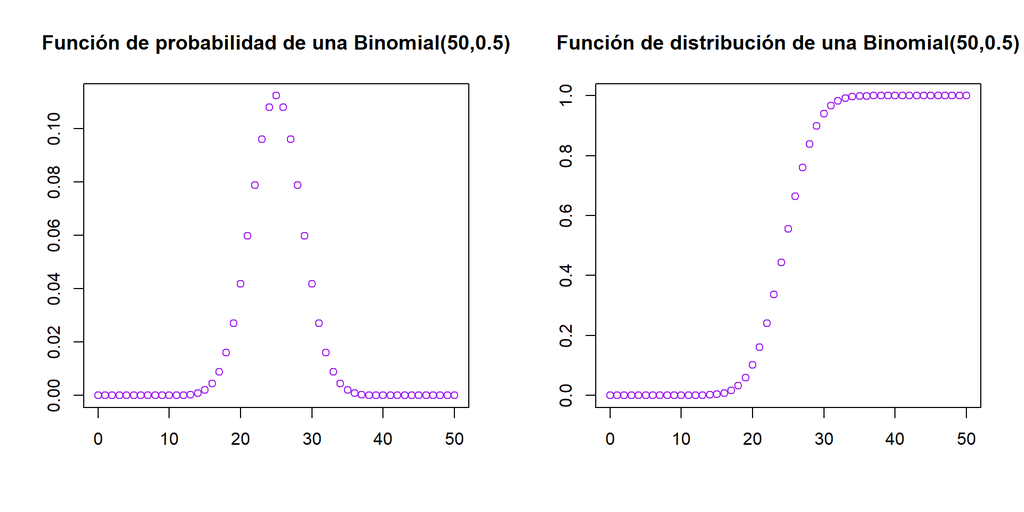

```r
 #Se lleva a cabo el experimento 50 veces (n) con probabilidad de 0.5 (p)
par(mfrow = c(1,2))
plot(0:50,dbinom(0:50,50,0.5),col = "purple", xlab = "", ylab = "", main = "Función de probabilidad de una Binomial(50,0.5)")
plot(0:50, pbinom(0:50,50,0.5),col = "purple", xlab = "", ylab = "", main = "Función de distribución de una Binomial(50,0.5)", ylim = c(0,1))
```

```r
par(mfrow= c(1,1))
```

## 2. Distribución Binomial en `R` y `Python`

El código de la distribución Binomial:

- En **`R`** tenemos las funciones del paquete básico “stats”: **`dbinom(x, size, prob), pbinom(q,size, prob), qbinom(p, size, prob), rbinom(n, size, prob)`** donde **`prob`** es la probabilidad de éxito y **`size`** el número de ensayos del experimento.
- En **`Python`** tenemos las funciones del paquete **`scipy.stats.binom`**: **`pmf(k,n,p), cdf(k,n,p), ppf(q,n,p), rvs(n, p, size)`** donde **`p`** es la probabilidad de éxito y **`n`** el número de ensayos del experimento.

## 3. Ejemplos en código para la distribución Binomial (R y Python

Sea nuestra Binomial la siguiente: $X = B(n = 30, p = 0.6)$, denotaremos su función de probabilidad y de distribución.

Función de probabilidad:
$$f(k) = {30\choose k}0.6^k(1-0.6)^{30-k}$$

Función de distribución:
$$F(x) = \left\{
\begin{array}{cl}
0 & \text{si } x<0
\\ \sum_{k=0}^xf(k) & \text{si } 0\le x<30
\\ 1 & \text{si } x\ge 30
\end{array}
\right.$$

#### **Ejemplo en R**

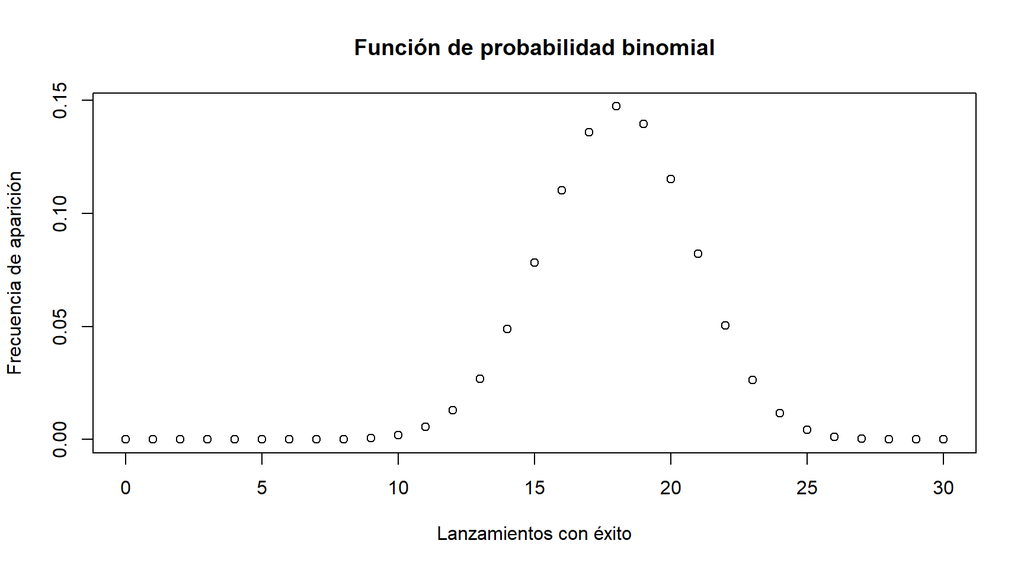

```r
#Defino el nº de ensayos y la probabilidad
n = 30
p = 0.6

#Función de probabilidad del dominio, con muesta "n" y probabilidad "p"
plot(0:n, dbinom(0:n, size = n, prob = p),
     title("Función de probabilidad binomial"),
     ylab = "Frecuencia de aparición",
     xlab = "Lanzamientos con éxito")
```

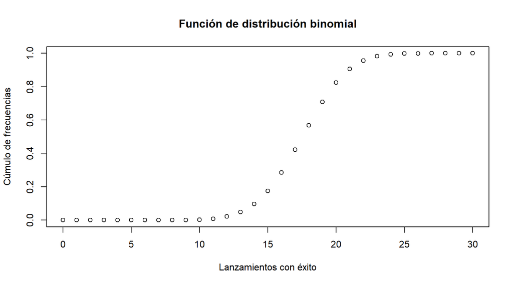

```r
#Función de distribución del dominio, con muesta "n" y probabilidad "p"
plot(0:n, pbinom(0:n, size = n, prob = p),
     title("Función de distribución binomial"),
     ylab = "Cúmulo de frecuencias",
     xlab = "Lanzamientos con éxito")
```

```r
#Sacamos la mediana
qbinom(0.5, n, p)
```

```
## [1] 18
```

```r
#Sacamos el cuantil 0.25
qbinom(0.25, n, p)
```

```
## [1] 16
```

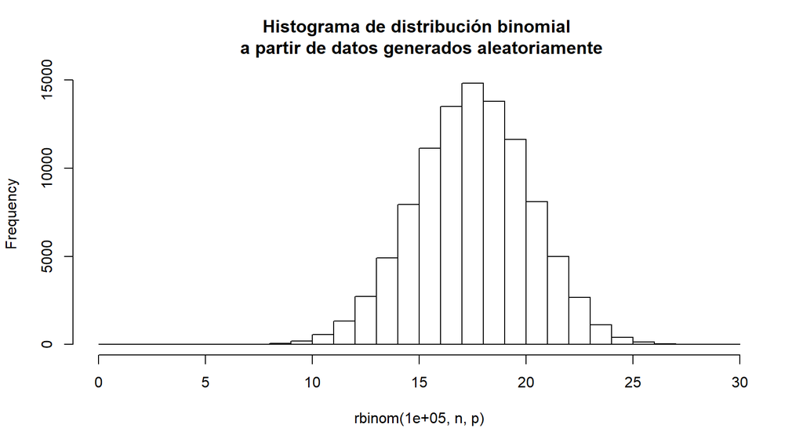

```r
#Generamos datos aleatorios y representamos un histograma
hist(rbinom(100000, n, p),
     breaks = 0:n,
     main = "Histograma de distribución binomial \n a partir de datos generados aleatoriamente")
```

#### **Ejemplo en Python**

Vete al script de Python del presente tema 6.